# PADP8120 Midterm Fall 2015

### 6. (4 points) What is the probability that a randomly selected student in the dataset received a voucher and scored above the 50th percentile on the math pre-test?

```r
#First, we will use the Shapiro-Wilks test to formally check if the sample (students that received a score on the math pre-test) is normally distributed.
shapiro <- shapiro.test(nyc_clean$y0_math_percentile)
```

Our resulting p-value is < 2.2e-16, or less than 0.00000000000000022. We can use in-line r code to find out that the actual p-value is 1.667620410^{-38}. With a p-value far less than .05, we have an infinitesimal chance of a normal distribution. We can reject the null hypothesis of normality.

```r
#Next, we can find out more about the value of the math pre-test sample, including the value of the Mean or 50% percentile mark:
summary(nyc_clean$y0_math_percentile)
```

```
##    Min. 1st Qu.  Median    Mean 3rd Qu.    Max.
##    0.00    2.00    9.00   16.42   25.00   98.00
```

```r
quantile(nyc_clean$y0_read_percentile, c(.25, .50,  .75, .90, .99))
```

```
##   25%   50%   75%   90%   99%
##  4.00 16.00 34.00 56.00 85.92
```

```r
#In the following frequency table, Treatment (Receiving a Voucher) will be the rows, scoring above 16.42 (scoring above the mean) will be the columns.
mytable <- table(nyc_clean$Treatment==1, nyc_clean$y0_math_percentile>16)

#We can conduct a chi-square test on this table to determine if these are independent outcomes.
chisq.test(mytable)
```

```
##
##  Pearson's Chi-squared test with Yates' continuity correction
##
## data:  mytable
## X-squared = 0.30993, df = 1, p-value = 0.5777
```

As the p value of the Pearson’s chi-square test is signficantly above .05, we do not reject the null hypothesis that receiving a voucher is independent of scoring above 50. This allows us to now use the multiplicaton rule for independent processes. So: $P(AandB)=P(A)xP(B)$.

```r
#Now, let's see the results of the table itself
table(nyc_clean$Treatment==1, nyc_clean$y0_math_percentile>16)
```

```
##
##         FALSE TRUE
##   FALSE   441  233
##   TRUE    499  282
```

The probability that a randomly selected student in the dataset received a voucher and scored above the 50th percentile on the math pre-test is 19%

### 7. (4 points) What is the probability that a randomly selected student who received a voucher group scored above the 50th percentile on the math pre-test?

It is not immediately clear how this question is different than Question 6. Both seem to ask what is the probability that a randomly selected student in the dataset received a voucher and scored above the 50th percentile. I’m not sure what the significance of “group scored” or how one could receive a “voucher group” so I’m not sure how to proceed.My best guess is that one of these questions was intended to ask the odds of both events occuring (“AND”) as opposed to the odds that one or the other event occurs (“OR”), so I have solved this question for the or.

As opposed to the previous question, where we used the P(AandB)=P(A)xP(B) formula, we instead use the following formula: $P(A or B) = P(A) + P(B) - P(A and B)$ We can use the values we calculated in Question 6 to fill in this probabilities. Therefore we know that:

```r
#P(A or B) = P(A) + P(B) - P(A and B)
515/1455 + 781/1455 - 282/1455
```

```
## [1] 0.6969072
```

The probability that a randomly selected student received a voucher OR scored above the 50th percentile on the math pre-test is 69.6%

### 8. (4 points) We are interested in studying whether the change in math scores after one year is different for students who receive a voucher versus those who do not. Write the null and alternative hypotheses in words and then using symbols.

```r
#Before we begin, we need to know the average change in math scores after one year (from year 0 to year 1) for the students that did not receive a voucher:
mathchg <- mean(nyc_clean$y1_math_percentile[nyc_clean$Treatment==0])-mean(nyc_clean$y0_math_percentile[nyc_clean$Treatment==0])
```

Now that we know that the average change in math scores after one year is 6.49, we can construct our hypotheses:

**Null Hypothesis:** Students who receive a voucher experience a change in math scores after one year that is equal to 6.49.

**Alternative Hypothesis:** Students who receive a voucher experience a change in math scores after one year that is not equal to 6.49.

$H_0: \mu == 6.49$ $H_A: \mu != 6.49$

### 9. (6 points) Evaluate the hypothesis from 8 at a significance level of a=0.05 and state your conclusion in 1-2 sentences.

```r
#First, we will create a new variable that consists of the differences in math scores after one year for each student:
nyc_clean$MathAfter <- (nyc_clean$y1_math_percentile - nyc_clean$y0_math_percentile)
```

We now have a variable that we can test. we are interested in positive and negative changes, so we are interested in two-tailed tests.

```r
t.test(x=nyc_clean$MathAfter[nyc_clean$Treatment==1],mu=mathchg,alternative='two.sided')
```

```
##
##  One Sample t-test
##
## data:  nyc_clean$MathAfter[nyc_clean$Treatment == 1]
## t = 0.89229, df = 780, p-value = 0.3725
## alternative hypothesis: true mean is not equal to 6.486647
## 95 percent confidence interval:
##  5.744653 8.465335
## sample estimates:
## mean of x
##  7.104994
```

Note: As means of double checking the quality of our calculation, we can confirm that the mean is within the 95 percent confidence interval.

### 10. (2 points) Would your conclusion change at $\alpha = 0.10$? Why or why not?

No our conclusion would not change. If our alpha was increased to .10, reflecting a 90% confidence interval, we would still be unable to reject the null. Our p-value of 0.3725 is still significantly higher than the .10 alpha.

### 11. (6 points) There are four assumptions that hold for the test above to be valid: independence within groups, independence between groups, sample sizes both above 30, and symmetric distributions. Are you satisfied that each of these are upheld? Is there anything in particular that you might be concerned about?

```r
#First, I would like to collect some basic information on each group
library(pastecs)
stat.desc(nyc_clean$MathAfter[nyc_clean$Treatment==1])
```

```
##      nbr.val     nbr.null       nbr.na          min          max
##  781.0000000   30.0000000    0.0000000  -63.0000000   96.0000000
##        range          sum       median         mean      SE.mean
##  159.0000000 5549.0000000    4.0000000    7.1049936    0.6929873
## CI.mean.0.95          var      std.dev     coef.var
##    1.3603411  375.0607571   19.3664854    2.7257569
```

```r
stat.desc(nyc_clean$MathAfter[nyc_clean$Treatment==0])
```

```
##      nbr.val     nbr.null       nbr.na          min          max
##  674.0000000   36.0000000    0.0000000  -83.0000000   97.0000000
##        range          sum       median         mean      SE.mean
##  180.0000000 4372.0000000    4.0000000    6.4866469    0.8031588
## CI.mean.0.95          var      std.dev     coef.var
##    1.5769985  434.7732241   20.8512164    3.2144830
```

```r
#Note: The # of Values is 1 more than accurate; it does not take into account the header
```

Assumption One: Independence Within Groups: Independence is a good assumption. It seems unlikely the performance of one student within the group would influence the performance of another student within the same group.

Assumption Two: Independence Between Groups: Independence is again a good assumption. It seems unlikely that the performance of a student in a group could influence the performance of a student in another group.

Assumption Four: Symmetric Distributions

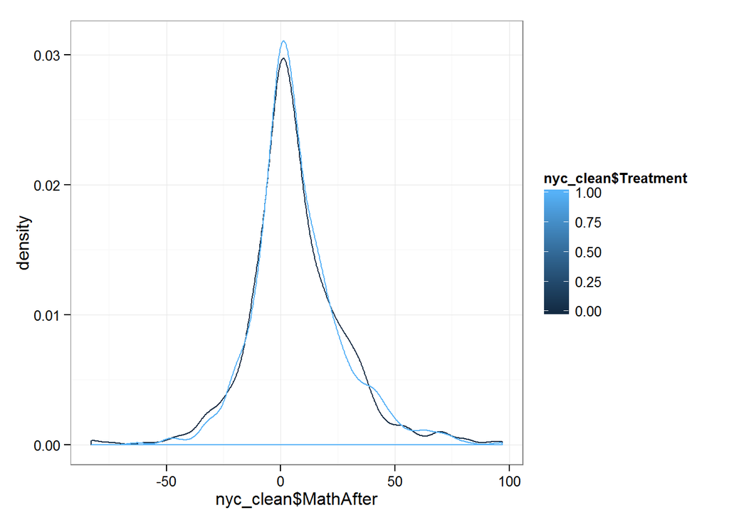

```r
#Let's plot the two groups to take a look at their symmetry:
library(ggplot2)
ggplot(nyc_clean,aes(x=nyc_clean$MathAfter,group=nyc_clean$Treatment,col=nyc_clean$Treatment)) + geom_density() + theme_bw()
```

As we see, symmetry is supported for both groups. We are satisfied that each of these are upheld. It feels callous to say there is nothing we are concerned about (especially on a test where I’m certain we are meant to notice something), but all I can mention is that the symmetry may not be quite perfect. We can see some changes on the right side of the distribution, possibly indicating some important phenomena. Mostly, however, I think we should feel satisfied.

### 12. (4 points) Next, you are asked to evaluate whether students in the treatment group differ in terms of their reading ability from the pre-test to the year 1 post-test. Write out the null and alternative hypotheses in words and then in symbols.

```r
#Before we begin, we need to know the average change in reading scores after one year (from year 0 to year 1) for the students that did not receive a voucher:
readchg <- mean(nyc_clean$y1_read_percentile[nyc_clean$Treatment==0])-mean(nyc_clean$y0_read_percentile[nyc_clean$Treatment==0])
```

Now that we know that the average change in read scores after one year is 1.27, we can construct our hypotheses:

**Null Hypothesis:** Students who receive a voucher experience a change in reading scores after one year that is equal to 1.27.

**Alternative Hypothesis:** Students who receive a voucher experience a change in read scores after one year that is not equal to 1.27.

$H_0: \mu == 1.27$ $H_A: \mu != 1.27$

### 13. (6 points) Conduct a t-test to evaluate this hypothesis at $\alpha = 0.01$ significance level. Interpret your results in 1-2 complete sentences.

```r
#First, we will create a new variable that consists of the differences in math scores after one year for each student:
nyc_clean$ReadAfter <- (nyc_clean$y1_read_percentile - nyc_clean$y0_read_percentile)
```

We now have a variable that we can test. we are interested in positive and negative changes, so we are interested in two-tailed tests.

```r
t.test(x=nyc_clean$ReadAfter[nyc_clean$Treatment==1],mu=readchg,conf.level = 0.99,alternative='two.sided')
```

```
##
##  One Sample t-test
##
## data:  nyc_clean$ReadAfter[nyc_clean$Treatment == 1]
## t = 2.1198, df = 780, p-value = 0.03434
## alternative hypothesis: true mean is not equal to 1.265579
## 99 percent confidence interval:
##  0.9425593 4.5503984
## sample estimates:
## mean of x
##  2.746479
```

Note: As means of double checking the quality of our calculation, we can confirm that the mean is within the 99 percent confidence interval.

### 14. (4 points) Explain how you could evaluate the hypothesis above using a confidence interval instead of a p-value.

As explained on page 182 of our OpenIntro Statistics book, we can confidently test hypotheses using confidence intervals. To do so, we look to see if the mean falls within the range of the plausibe values from the confidence interval. In this scenario, that means we would look for the average to fall between the 99% confidence interval of 0.9425593 to 4.5503984. Because the average (1.27) does fall in that range, we “cannot say the null hypothesis is implausible. That is, we fail to reject the null hypothesis, H_0”

If necessary, we could also construct the interval at hand, using a 2.33 z score and creating it step by step. However, our t-test in Q.13 revealed our confidence interval and gave us the necessary information to answer this question.

### 16. (8 points) Perform a test of whether the average math pre-test score differs by grade level at $\alpha = 0.10$ significance level. Write out your hypothesis in symbols, perform the test, and then report your findings in a complete sentence.

**Null Hypothesis:** Average math pre-test scores are the same at all grade levels.

**Alternative Hypothesis:** Average math pre-test scores are not the same at all grade levels.

$H_0: y0_math_percentile == y0_math_percentile[Grade]`$ $H_A: y0_math_percentile != y0_math_percentile[Grade]`$

```r
#We conduct an ANOVA to see whether there is a significant difference in average math pre-test scores by students in different grade levels.
aovmath <- aov(nyc_clean$y0_math_percentile ~ as.character(nyc_clean$Grade))
summary(aovmath)
```

```
##                                 Df Sum Sq Mean Sq F value   Pr(>F)
## as.character(nyc_clean$Grade)    6  19851    3309   9.287 5.26e-10 ***
## Residuals                     1410 502309     356
## ---
## Signif. codes:  0 '***' 0.001 '**' 0.01 '*' 0.05 '.' 0.1 ' ' 1
## 38 observations deleted due to missingness
```

The resulting p-value is 5.26e-10, an extremely small number, certainly much smaller than a .10 alpha. We reject the null and can support the claim that average math pre-test score differs by grade level.

### 17. (8 points) The NYC School District considers students who perform at or above the 50th percentile to be “passing”. At a 99% significance level, is the proportion of all students in the sample (voucher and no-voucher) that are considered to be passing in math significantly different between the pre-test and year 1 post-test?

```r
#Let's determine the 50th percentile for each year
#First, let's look at pre-test:
summary(nyc_clean$y0_math_percentile)
```

```
##    Min. 1st Qu.  Median    Mean 3rd Qu.    Max.
##    0.00    2.00    9.00   16.42   25.00   98.00
```

```r
quantile(nyc_clean$y0_read_percentile, c(.25, .50,  .75, .90, .99))
```

```
##   25%   50%   75%   90%   99%
##  4.00 16.00 34.00 56.00 85.92
```

```r
#Now, let's look at the year 1 post-test:
summary(nyc_clean$y1_math_percentile)
```

```
##    Min. 1st Qu.  Median    Mean 3rd Qu.    Max.
##    0.00    5.00   15.00   23.24   36.00   99.00
```

```r
quantile(nyc_clean$y1_read_percentile, c(.25, .50,  .75, .90, .99))
```

```
##  25%  50%  75%  90%  99%
##  7.0 18.0 37.5 57.0 85.0
```

```r
#Now, let's look at proportions:
#Proportions for Pre-Test/Year 0
table(nyc_clean$y0_math_percentile>16)
```

```
##
## FALSE  TRUE
##   940   515
```

```r
#Proportions for Post-Test/Year 1
table(nyc_clean$y0_math_percentile>18)
```

```
##
## FALSE  TRUE
##   962   493
```

### 18. (6 points) Make a boxplot that compares the distribution of math scores between the pre-test and year 1 post-test for all students. Do your best to make the figure “publishable” by giving it clear axis titles, legend labels, and other aesthetic improvements. In no more than 2-3 sentences, describe how your figure supports (or does not support) your finding from question 17.

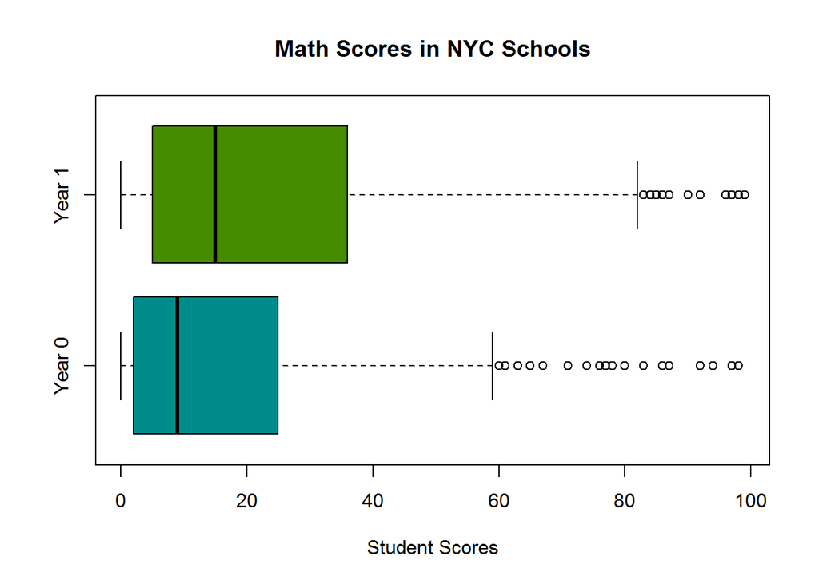

### 19. (4 points) Consider the correlation between math percentile and reading percentile for year 1 test scores. Compute Pearson’s `r` between these two variables. Is the correlation higher or lower than you would have expected?

```r
cor(nyc_clean$y1_read_percentile, nyc_clean$y1_math_percentile, method = c("pearson"))
```

```
## [1] 0.6164846
```

### 20. (6 points) You might argue that percentiles are actually rank-order data and not ratio-level data. For rank-order data, a more appropriate correlation measure is Spearman’s $\rho$, which is a rank correlation. Compute $\rho$ and contrast the results from $r$ (for question S above). Why do the results differ?

I am answering with the assumption that question S is referring to question 19

```r
cor(nyc_clean$y1_read_percentile, nyc_clean$y1_math_percentile, method = c("spearman"))
```

```
## [1] 0.5848958
```

The result is .5848958. The results are close, but differ by .0315888. If we assume that percentiles are linear, than Pearson’s is the better choice. If, as the question suggests, we consider the data to be rank-order or monotonic (basically, consisting of a certain, well-preserved order) than we may prefer to use Spearman’s. Percentiles may indeed be more appropriate for this as it is likely there is so social/power/cast/ranking system, where certain students consistently perform along a preserved rank. The larger coefficient produced by Pearson’s suggests that this set is closer to being linear than it is monotonic, a fact that it is not surprising in a school setting where there may be trends, but not occuring in a completely monotonic and predictable rank.